# BA 810 Project Final Version

Team 6: Ji Qi, Yuxuan Mei, Yihan Jia, Yuhan Wang, Mochi Zhang

9/27/2021

# Features

`enrollee_id` : Unique ID for candidate

`city`: City code

`city_development_index` : Developement index of the city (scaled)

`gender`: Gender of candidate

`relevent_experience`: Relevant experience of candidate

`enrolled_university`: Type of University course enrolled if any

`education_level`: Education level of candidate

`major_discipline` :Education major discipline of candidate

`experience`: Candidate total experience in years

`company_size`: No of employees in current employer’s company

`company_type` : Type of current employer

`lastnewjob`: Difference in years between previous job and current job

`training_hours`: training hours completed

`target`: 0 – Not looking for job change, 1 – Looking for a job change

# Load the dataset

```r
library(data.table)
```

```r
library(ggplot2)
dd <- fread('/Users/moonqj/Desktop/Boston University/Semester/Fall 2021/BA 810/Project/data/aug_train.csv')
str(dd)
```

```
## Classes 'data.table' and 'data.frame':   19158 obs. of  14 variables:
##  $ enrollee_id           : int  8949 29725 11561 33241 666 21651 28806 402 27107 699 ...
##  $ city                  : chr  "city_103" "city_40" "city_21" "city_115" ...
##  $ city_development_index: num  0.92 0.776 0.624 0.789 0.767 0.764 0.92 0.762 0.92 0.92 ...
##  $ gender                : chr  "Male" "Male" "" "" ...
##  $ relevent_experience   : chr  "Has relevent experience" "No relevent experience" "No relevent experience" "No relevent experience" ...
##  $ enrolled_university   : chr  "no_enrollment" "no_enrollment" "Full time course" "" ...
##  $ education_level       : chr  "Graduate" "Graduate" "Graduate" "Graduate" ...
##  $ major_discipline      : chr  "STEM" "STEM" "STEM" "Business Degree" ...
##  $ experience            : chr  ">20" "15" "5" "<1" ...
##  $ company_size          : chr  "" "50-99" "" "" ...
##  $ company_type          : chr  "" "Pvt Ltd" "" "Pvt Ltd" ...
##  $ last_new_job          : chr  "1" ">4" "never" "never" ...
##  $ training_hours        : int  36 47 83 52 8 24 24 18 46 123 ...
##  $ target                : num  1 0 0 1 0 1 0 1 1 0 ...
##  - attr(*, ".internal.selfref")=<externalptr>
```

# Information of the dataset

```r
# how many rows and columns
dim(dd)
```

```
## [1] 19158    14
```

```r
# basic stats
summary(dd)
```

```
##   enrollee_id        city           city_development_index    gender
##  Min.   :    1   Length:19158       Min.   :0.4480         Length:19158
##  1st Qu.: 8554   Class :character   1st Qu.:0.7400         Class :character
##  Median :16982   Mode  :character   Median :0.9030         Mode  :character
##  Mean   :16875                      Mean   :0.8288
##  3rd Qu.:25170                      3rd Qu.:0.9200
##  Max.   :33380                      Max.   :0.9490
##  relevent_experience enrolled_university education_level    major_discipline
##  Length:19158        Length:19158        Length:19158       Length:19158
##  Class :character    Class :character    Class :character   Class :character
##  Mode  :character    Mode  :character    Mode  :character   Mode  :character
##
##
##
##   experience        company_size       company_type       last_new_job
##  Length:19158       Length:19158       Length:19158       Length:19158
##  Class :character   Class :character   Class :character   Class :character
##  Mode  :character   Mode  :character   Mode  :character   Mode  :character
##
##
##
##  training_hours       target
##  Min.   :  1.00   Min.   :0.0000
##  1st Qu.: 23.00   1st Qu.:0.0000
##  Median : 47.00   Median :0.0000
##  Mean   : 65.37   Mean   :0.2493
##  3rd Qu.: 88.00   3rd Qu.:0.0000
##  Max.   :336.00   Max.   :1.0000
```

# Summary of the missing values

```r
sum(dd == '')
```

```
## [1] 20733
```

```r
check_missing <- function(x) {
  sum(is.null(x) | x == '')}
a <- data.frame(sapply(dd, check_missing))
setDT(a, keep.rownames = TRUE)[]
```

```
##                         rn sapply.dd..check_missing.
##  1:            enrollee_id                         0
##  2:                   city                         0
##  3: city_development_index                         0
##  4:                 gender                      4508
##  5:    relevent_experience                         0
##  6:    enrolled_university                       386
##  7:        education_level                       460
##  8:       major_discipline                      2813
##  9:             experience                        65
## 10:           company_size                      5938
## 11:           company_type                      6140
## 12:           last_new_job                       423
## 13:         training_hours                         0
## 14:                 target                         0
```

```r
colnames(a) <- c ('variable_name', 'the_count_of_missing_values')

a[the_count_of_missing_values > 0][order(-the_count_of_missing_values)]
```

```
##          variable_name the_count_of_missing_values
## 1:        company_type                        6140
## 2:        company_size                        5938
## 3:              gender                        4508
## 4:    major_discipline                        2813
## 5:     education_level                         460
## 6:        last_new_job                         423
## 7: enrolled_university                         386
## 8:          experience                          65
```

# Summary of notnull values

```r
check_notnull <- function(x) {
  sum(x != '')}
b <- setDT(data.frame(sapply(dd, check_notnull)),  keep.rownames = TRUE)
colnames((b))
```

```
## [1] "rn"                        "sapply.dd..check_notnull."
```

```r
b[,.(rn,(sapply.dd..check_notnull.))] [order(V2)]
```

```
##                         rn    V2
##  1:           company_type 13018
##  2:           company_size 13220
##  3:                 gender 14650
##  4:       major_discipline 16345
##  5:        education_level 18698
##  6:           last_new_job 18735
##  7:    enrolled_university 18772
##  8:             experience 19093
##  9:            enrollee_id 19158
## 10:                   city 19158
## 11: city_development_index 19158
## 12:    relevent_experience 19158
## 13:         training_hours 19158
## 14:                 target 19158
```

# Specific info of each column

```r
for (i in colnames(dd))
{
print(unique(dd[, i, with = FALSE]))
}
```

```
##        enrollee_id
##     1:        8949
##     2:       29725
##     3:       11561
##     4:       33241
##     5:         666
##    ---
## 19154:        7386
## 19155:       31398
## 19156:       24576
## 19157:        5756
## 19158:       23834
##          city
##   1: city_103
##   2:  city_40
```

[output cut: 198 more lines]

```r
for (i in colnames(dd))
{
print((dd[, .N, by = i ]))
}
```

```
##        enrollee_id N
##     1:        8949 1
##     2:       29725 1
##     3:       11561 1
##     4:       33241 1
##     5:         666 1
##    ---
## 19154:        7386 1
## 19155:       31398 1
## 19156:       24576 1
## 19157:        5756 1
## 19158:       23834 1
##          city    N
##   1: city_103 4355
##   2:  city_40   68
```

[output cut: 198 more lines]

# Fill the missing data

company_type 6140  
company_size 5938  
gender 4508  
major_discipline 2813  
education_level 460  
last_new_job 423  
enrolled_university 386 experience 65

```r
# company_type  6140, fill with the mode value
company_type_mode <- dd[, max(.N), by = company_type][V1 == max(V1),company_type]
dd_cleaned <- dd[(company_type == ''), company_type := company_type_mode]
print((dd_cleaned[, .N, by = company_type]))
```

```
##           company_type     N
## 1:             Pvt Ltd 15957
## 2:      Funded Startup  1001
## 3: Early Stage Startup   603
## 4:               Other   121
## 5:       Public Sector   955
## 6:                 NGO   521
```

```r
# company_size 5938, fill with the mode value

dd_cleaned <- dd[(company_size == '10/49'), company_size := '10-49' ]
company_size_mode <-dd[company_size != '', max(.N), by = company_size][V1 == max(V1),company_size]
dd_cleaned <- dd[(company_size == ''), company_size := company_size_mode]
print((dd_cleaned[, .N, by = company_size]))
```

```
##    company_size    N
## 1:        50-99 9021
## 2:          <10 1308
## 3:       10000+ 2019
## 4:    5000-9999  563
## 5:    1000-4999 1328
## 6:        10-49 1471
## 7:      100-500 2571
## 8:      500-999  877
```

```r
# gender    4508, classified these unknown gender as other

dd_cleaned <- dd[gender == '', gender := 'Other' ]
print((dd_cleaned[, .N, by = gender]))
```

```
##    gender     N
## 1:   Male 13221
## 2:  Other  4699
## 3: Female  1238
```

```r
# major_discipline  2813, fill with the mode value
major_discipline__mode <-dd[major_discipline != '', max(.N), by = major_discipline][V1 == max(V1),major_discipline]
dd_cleaned <- dd[(major_discipline == ''), major_discipline := major_discipline__mode]
print((dd_cleaned[, .N, by = major_discipline]))
```

```
##    major_discipline     N
## 1:             STEM 17305
## 2:  Business Degree   327
## 3:             Arts   253
## 4:       Humanities   669
## 5:         No Major   223
## 6:            Other   381
```

```r
# education_level   460, fill with the "Primary School"
dd_cleaned <- dd[(education_level == ''), education_level :=  'Primary School']
print((dd_cleaned[, .N, by = education_level]))
```

```
##    education_level     N
## 1:        Graduate 11598
## 2:         Masters  4361
## 3:     High School  2017
## 4:  Primary School   768
## 5:             Phd   414
```

```r
# last_new_job  423 , fill with the mode value
last_new_job_mode <-dd[last_new_job != '', max(.N), by = last_new_job][V1 == max(V1),last_new_job]
dd_cleaned <- dd[(last_new_job == ''), last_new_job := last_new_job_mode]
print((dd_cleaned[, .N, by = last_new_job]))
```

```
##    last_new_job    N
## 1:            1 8463
## 2:           >4 3290
## 3:        never 2452
## 4:            4 1029
## 5:            3 1024
## 6:            2 2900
```

```r
# enrolled_university   386
enrolled_university_mode <-dd[enrolled_university!= '', max(.N), by = enrolled_university][V1 == max(V1),enrolled_university]
dd_cleaned <- dd[(enrolled_university == ''),enrolled_university := enrolled_university_mode]
print((dd_cleaned[, .N, by = enrolled_university]))
```

```
##    enrolled_university     N
## 1:       no_enrollment 14203
## 2:    Full time course  3757
## 3:    Part time course  1198
```

```r
# experience    65, classified NA as '<1', fill with the mode value
dd_cleaned[experience == '', experience := NA]

experience__mode <-dd[experience != '', max(.N), by = experience][V1 == max(V1),experience]

dd_cleaned[is.na(experience) , experience := experience__mode]

dd_cleaned[(experience == '>20'), experience := 21]

dd_cleaned[(experience == '<1'), experience := 0]

# change the datatype of experience into numeric
dd_cleaned[ , experience := as.numeric(experience)]

print((dd_cleaned[, .N, by = experience]))
```

```
##     experience    N
##  1:         21 3351
##  2:         15  686
##  3:          5 1430
##  4:          0  522
##  5:         11  664
##  6:         13  399
##  7:          7 1028
##  8:         17  342
##  9:          2 1127
## 10:         16  508
## 11:          1  549
## 12:          4 1403
## 13:         10  985
## 14:         14  586
## 15:         18  280
## 16:         19  304
## 17:         12  494
## 18:          3 1354
## 19:          6 1216
## 20:          9  980
## 21:          8  802
## 22:         20  148
##     experience    N
```

```r
# Drop 'enrollee_id', 'city' columns
dd_cleaned[ , c('enrollee_id', 'city') := NULL]
```

```r
# Change the categorical variables into dummy variables

install.packages('fastDummies', repos= 'https://github.com/jacobkap/fastDummies.git')
library(fastDummies)
results <- fastDummies::dummy_cols(dd_cleaned, remove_first_dummy = TRUE)

library(data.table)

setnames(results, "relevent_experience_No relevent experience", "relevent_experience_No_relevent_experience")
setnames(results, "enrolled_university_Part time course", "enrolled_university_Part_time_course")
setnames(results, "education_level_High School", "education_level_High_School")
setnames(results, "education_level_Primary School", "education_level_Primary_School")
setnames(results, "company_size_10-49", "company_size_10_49")
setnames(results, "company_size_50-99", "company_size_50_99")
setnames(results, "company_type_Funded Startup", "company_type_Funded_Startup")

setnames(results, "company_size_100-500", "company_size_100_500")
setnames(results, "company_size_500-999", "company_size_500_999")
setnames(results, "company_size_1000-4999", "company_size_1000_4999")
setnames(results, "company_size_5000-9999", "company_size_5000_9999")
setnames(results, "company_type_Pvt Ltd", "company_type_Pvt_Ltd")
setnames(results, 'company_type_Public Sector', "company_type_Public_Sector")
setnames(results, 'major_discipline_No Major', "major_discipline_No_Major")
setnames(results, 'major_discipline_Business Degree', "major_discipline_Business_Degree")
setnames(results, 'company_size_10000+', "company_size_10000")
```

```r
write.csv(results, "~/cleaned_data_810_10_06.csv", row.names = FALSE)
```

# Exploratory Data Analysis

```r
library(ggplot2)
theme_Ji <- theme_bw()+
  theme(
    plot.title=element_text(hjust=0.5, vjust=0.5, face='bold.italic'),
    axis.text.x = element_text(face="bold", color="#993333",
                               size=10, angle=0),
    axis.text.y = element_text(face="bold", color="#993333",
                               size=10, angle=0),
    axis.title.x = element_text(color="black", size=14, face="bold"),
    axis.title.y = element_text(color="black", size=14, face="bold")
  )

theme_set(theme_Ji)
```

## Target Column Histogram

0 - Not looking for job change 1 – Looking for a job change

This dataset is imbalanced and the ratio of ‘0 - Not looking for job change’ to ‘1 – Looking for a job change’ is equal to 3 : 1

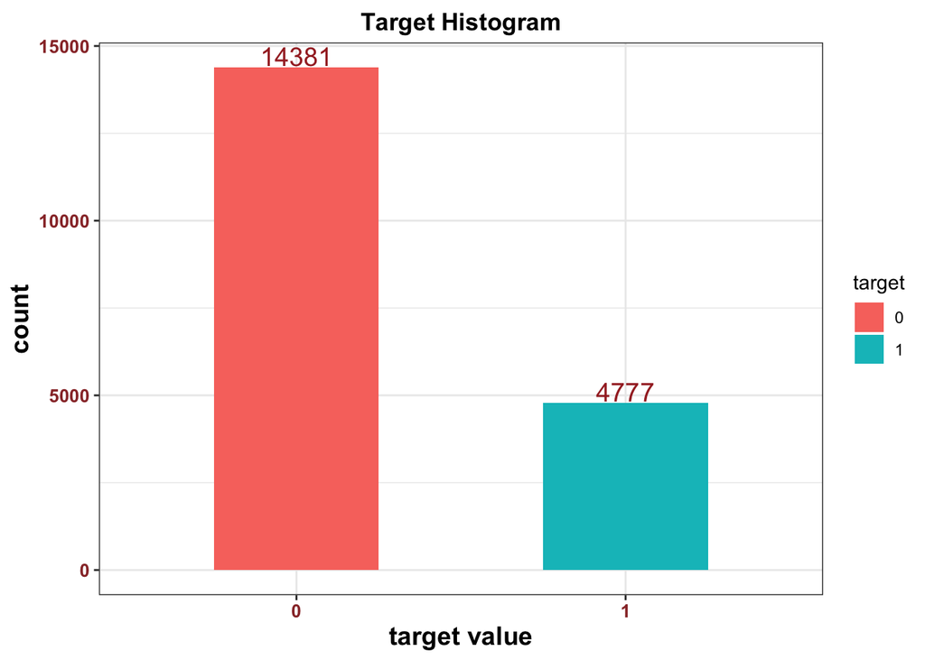

```r
# target column
target <- results[, target]
target <- data.table(target)


ggplot(results, aes(x = as.factor(target), fill = as.factor(target)))+
  geom_bar(stat = 'count', width = 0.5, position = 'dodge')+
  labs(x='target value', y = 'count')+
  ggtitle("Target Histogram") +
  geom_text(stat='count', aes(label=..count..), position = position_dodge(width = .5), vjust=-.1, size = 5, color = 'brown')+
  scale_fill_hue(name="target")+
  theme(
    plot.title=element_text(hjust=0.5, vjust=0.5, face='bold')
  )
```

## Gender Column Histogram

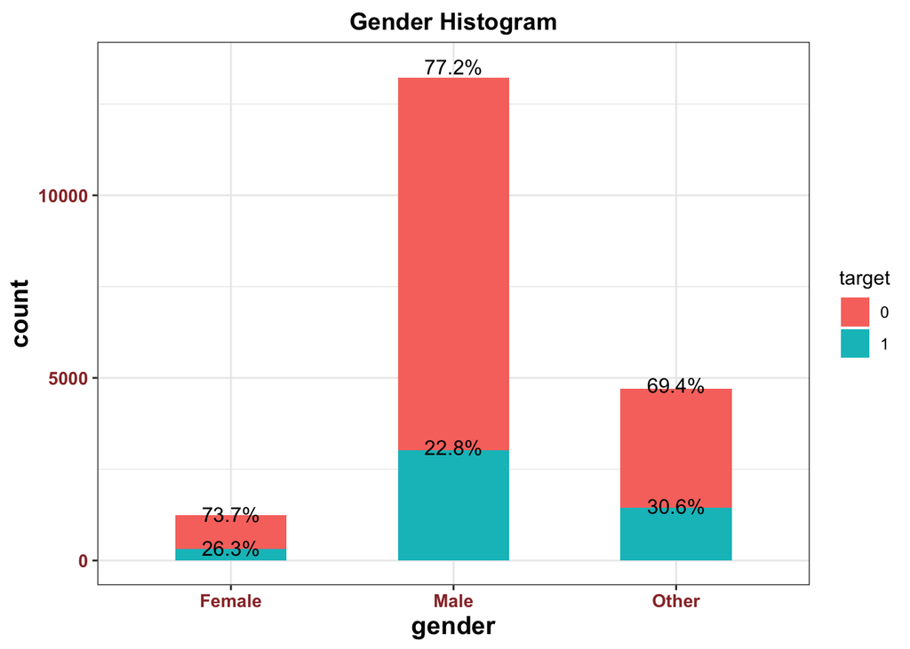

```r
gender <- results[, gender]
gender <- data.table(gender)


ggplot(results, aes(x = as.factor(gender), fill = as.factor(target)))+
  geom_bar(stat = 'count', width = 0.5, position = 'stack')+
  labs(x='gender', y = 'count')+
  ggtitle("Gender Histogram") +
  geom_text(stat='count', aes(label=scales::percent(..count../tapply(..count.., ..x.. ,sum)[..x..])), position = position_stack(vjust = 1.03) ,size = 4, color = 'black', check_overlap = TRUE)+
  scale_fill_hue(name="target")+
  theme(
    plot.title=element_text(hjust=0.5, vjust=0.5, face='bold')
  )
```

## Relative Experience Column Histogram Data Scientists without relevant experience have higher chances of leaving a Job

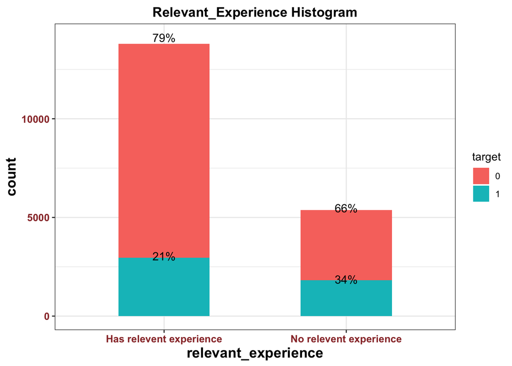

```r
relevent_experience <- results[, relevent_experience]
relevent_experience <- data.table(relevent_experience)


ggplot(results, aes(x = as.factor(relevent_experience), fill = as.factor(target)))+
  geom_bar(stat = 'count', width = 0.5, position = 'stack')+
  labs(x='relevant_experience', y = 'count')+
  ggtitle("Relevant_Experience Histogram") +
  geom_text(stat='count', aes(label=scales::percent(..count../tapply(..count.., ..x.. ,sum)[..x..])), position = position_stack(vjust = 1.03) ,size = 4, color = 'black', check_overlap = TRUE)+
  scale_fill_hue(name="target")+
  theme(
    plot.title=element_text(hjust=0.5, vjust=0.5, face='bold')
  )
```

## City_Development_Index Boxplot Candidates are going to look for a new job, since the city where they live has a lower city_development_index.

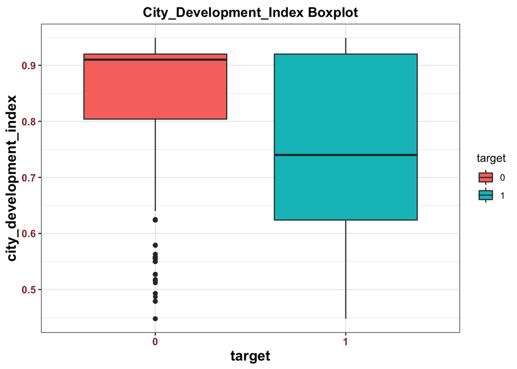

```r
ggplot(results, aes(x=as.factor(target), y=city_development_index, fill = as.factor(target))) +
  geom_boxplot()+
  labs(x='target', y = 'city_development_index')+
  scale_fill_hue(name="target")+
  ggtitle("City_Development_Index Boxplot") +
theme(legend.position="right", plot.title=element_text(hjust=0.5, vjust=0.5, face='bold'))
```

## Training Hours Violinplot

The data points of training hours are mainly located between 0 and 100 hours. No relationship between training hours and willingness to change their jobs

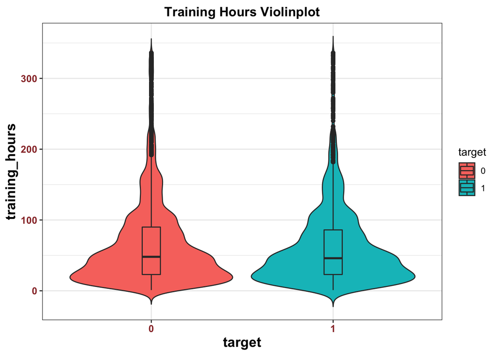

```r
ggplot(results, aes(x=as.factor(target), y=training_hours, fill = as.factor(target))) +
  geom_violin(trim=FALSE) +
  labs(x='target', y = 'training_hours')+
  stat_summary(fun.y=mean, geom="point", shape=23, size=2)+
  geom_boxplot(width=0.1)+
  scale_fill_hue(name="target")+
  ggtitle("Training Hours Violinplot")+
  theme(plot.title=element_text(hjust=0.5, vjust=0.5, face='bold'))
```

## Experience Violinplot

Most Data Scientists with less than 5 years’ experience are likely to resign their jobs Candidates with more than 10 years’ experience prefer to continue to work in the same company.

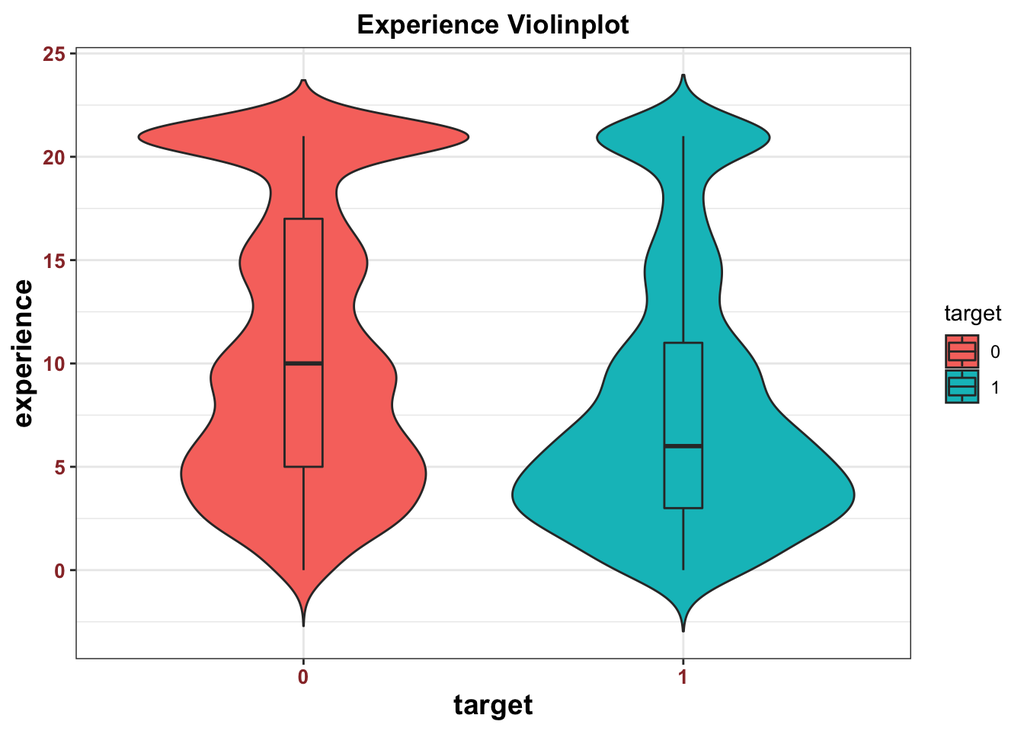

```r
ggplot(results, aes(x=as.factor(target), y=experience, fill = as.factor(target))) +
  geom_violin(trim=FALSE) +
  labs(x='target', y = 'experience')+
  stat_summary(fun.y=mean, geom="point", shape=23, size=2)+
  geom_boxplot(width=0.1)+
  scale_fill_hue(name="target")+
  ggtitle("Experience Violinplot")+
  theme(plot.title=element_text(hjust=0.5, vjust=0.5, face='bold'))
```

## Education_level Histogram

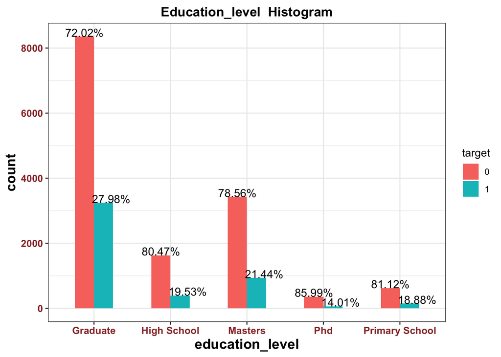

```r
ggplot(results, aes(x = as.factor(education_level ), fill = as.factor(target)))+
  geom_bar(stat = 'count', width = 0.5, position = 'dodge')+
  labs(x='education_level', y = 'count')+
  ggtitle("Education_level  Histogram") +
  geom_text(stat='count', aes(label=scales::percent(..count../tapply(..count.., ..x.. ,sum)[..x..])), position = position_dodge(width = 0.7) , vjust=-.01, hjust= 0.4,size = 4, color = 'black', check_overlap = TRUE)+
  scale_fill_hue(name="target")+
  theme(
    plot.title=element_text(hjust=0.5, vjust=0.5, face='bold')
  )
```

## Company Size Pie Chart

For the company size about 50 - 99, people are willing to leave their jobs.

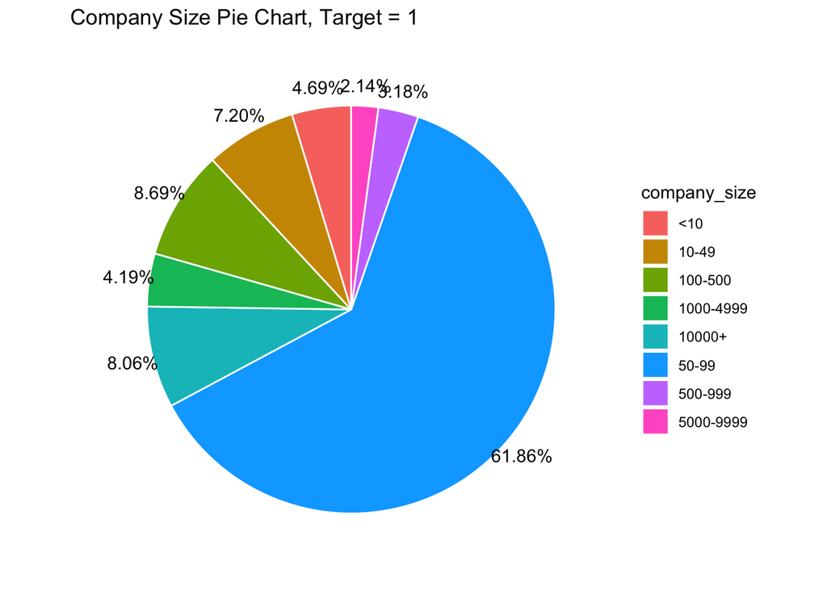

```r
com_size <- results[target == 1, .N, by = company_size]
com_size[, prop := .(scales :: percent(N/sum(N))),]

ggplot(com_size, aes(x = "", y = N, fill = company_size)) +
  geom_bar(width = 1, stat = "identity", color = "white") +
  coord_polar("y", start = 0)+
  geom_text(aes(x = 1.6, label = prop), color = "black", position = position_stack(vjust = .5))+
  ggtitle("Company Size Pie Chart, Target = 1") +
  theme(
    plot.title=element_text(hjust=-5, vjust=0.5, face='bold')
  )+
  theme_void()
```

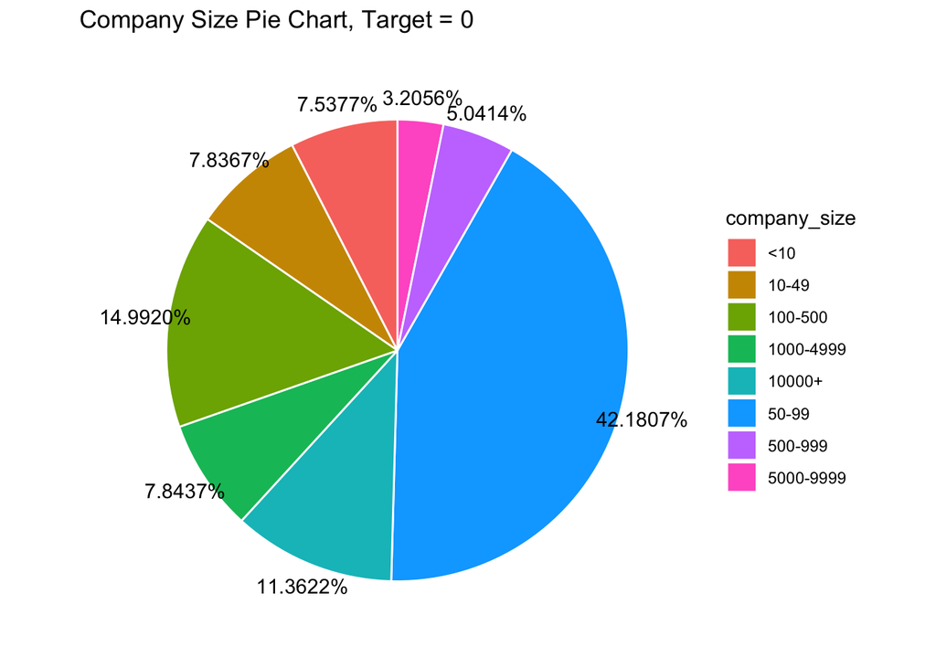

```r
com_size <- results[target == 0, .N, by = company_size]
com_size[, prop := .(scales :: percent(N/sum(N))),]

ggplot(com_size, aes(x = "", y = N, fill = company_size)) +
  geom_bar(width = 1, stat = "identity", color = "white") +
  coord_polar("y")+
  geom_text(aes(x = 1.6, label = prop), color = "black", position = position_stack(vjust = 0.5))+
  ggtitle("Company Size Pie Chart, Target = 0") +
  theme(
    plot.title=element_text(hjust=0.5, vjust=0.5, face='bold')
  )+
  theme_void()
```

## Last_New_Job Pie Chart

people whose last job was more than 4 years ago are willing to stay in the current company

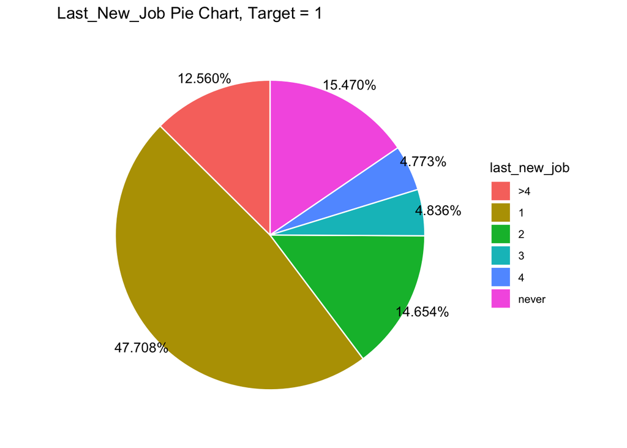

```r
com_size <- results[target == 1, .N, by = last_new_job]
com_size[, prop := .(scales :: percent(N/sum(N))),]

ggplot(com_size, aes(x = "", y = N, fill = last_new_job)) +
  geom_bar(width = 1, stat = "identity", color = "white") +
  coord_polar("y", start = 0)+
  geom_text(aes(x = 1.6, label = prop), color = "black", position = position_stack(vjust = .5))+
  ggtitle("Last_New_Job Pie Chart, Target = 1") +
  theme(
    plot.title=element_text(hjust=-5, vjust=0.5, face='bold')
  )+
  theme_void()
```

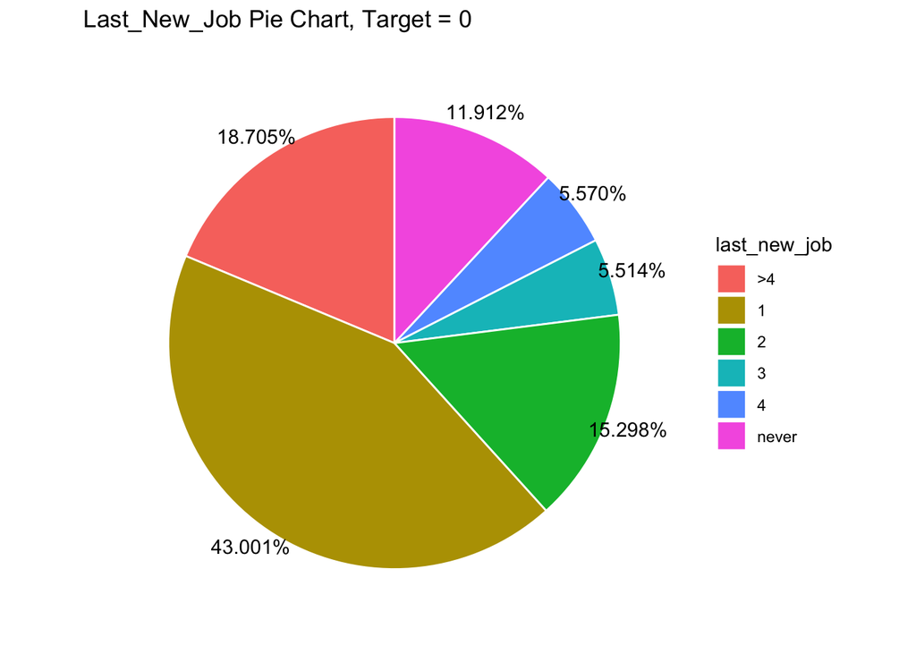

```r
com_size <- results[target == 0, .N, by = last_new_job]
com_size[, prop := .(scales :: percent(N/sum(N))),]

ggplot(com_size, aes(x = "", y = N, fill = last_new_job)) +
  geom_bar(width = 1, stat = "identity", color = "white") +
  coord_polar("y", start = 0)+
  geom_text(aes(x = 1.6, label = prop), color = "black", position = position_stack(vjust = .5))+
  ggtitle("Last_New_Job Pie Chart, Target = 0") +
  theme(
    plot.title=element_text(hjust=-5, vjust=0.5, face='bold')
  )+
  theme_void()
```

# Logistic regression (Generalized Linear Model)

## Train and test datasets

```r
logistic_data <- results[, c(1, 7, 11:43)]

# Total number of rows in the credit data frame
n <- nrow(results)

# Number of rows for the training set (70% of the dataset)
n_train <- round(0.7 * n)

# Create a vector of indices which is an 70% random sample
set.seed(123)
train_indices <- sample(1:n, n_train)

# Subset the credit data frame to training indices only
logistic_data_train <- logistic_data[train_indices, ]

# Exclude the training indices to create the test set
logistic_data_test <- logistic_data[-train_indices, ]
```

## Model 1 summary

summary(model)$coef coef(model)

It can be seen that only 15 out of the 34 predictors are significantly associated to the outcome. These include: city index, experience, training hours and so on.

The coefficient estimate of the variable company_size_50_99 is b = 0.8950371, which is positive. The positive coefficient for this predictor suggests that all other variables being equal, the people from company size (50-99) is less likely to stay. However the coefficient for the variable city_development_index is b = -5.7581439, which is negative. This means that an increase in city_development_index will be associated with a decreased probability of leaving the company.

```r
install.packages('caret', repos = 'https://github.com/topepo/caret/')
library(caret)
library(data.table)
ctrl <- trainControl(method = "repeatedcv", number = 10, savePredictions = TRUE)

mod_fit <- train(as.factor(target) ~ ., data = logistic_data_train,method="glm", family="binomial",
                 trControl = ctrl, tuneLength = 5)
summary(mod_fit)
```

```
##
## Call:
## NULL
##
## Deviance Residuals:
##     Min       1Q   Median       3Q      Max
## -2.0488  -0.6885  -0.4853   0.4320   2.7520
##
## Coefficients:
##                                              Estimate Std. Error z value
## (Intercept)                                 3.7102811  0.3069782  12.086
## city_development_index                     -5.7581439  0.1803836 -31.922
## experience                                 -0.0221689  0.0043040  -5.151
## training_hours                             -0.0008811  0.0003716  -2.371
## gender_Male                                -0.1076848  0.0909151  -1.184
## gender_Other                               -0.0340240  0.0965996  -0.352
## relevent_experience_No_relevent_experience  0.4874858  0.0573494   8.500
## enrolled_university_no_enrollment          -0.2993169  0.0585413  -5.113
## enrolled_university_Part_time_course       -0.3400246  0.0991791  -3.428
## education_level_High_School                -0.8903066  0.0831953 -10.701
## education_level_Masters                    -0.2165801  0.0564288  -3.838
## education_level_Phd                        -0.4724900  0.1852336  -2.551
## education_level_Primary_School             -0.8702386  0.1255322  -6.932
## major_discipline_Business_Degree           -0.0664563  0.2551690  -0.260
## major_discipline_Humanities                 0.0452474  0.2277620   0.199
## major_discipline_No_Major                  -0.0659505  0.2792759  -0.236
## major_discipline_Other                     -0.0551606  0.2472235  -0.223
## major_discipline_STEM                      -0.1506507  0.1969069  -0.765
## company_size_10_49                          0.4190967  0.1266953   3.308
## company_size_50_99                          0.8950371  0.1076932   8.311
## company_size_100_500                       -0.0178484  0.1237403  -0.144
## company_size_500_999                        0.0160644  0.1549252   0.104
## company_size_1000_4999                      0.0261925  0.1416417   0.185
## company_size_5000_9999                      0.1914405  0.1742758   1.098
## company_size_10000                          0.1979870  0.1264493   1.566
## company_type_Funded_Startup                -0.4548826  0.1750622  -2.598
## company_type_NGO                            0.0027445  0.1996128   0.014
## company_type_Other                          0.4960505  0.2978521   1.665
## company_type_Public_Sector                  0.2229444  0.1718149   1.298
## company_type_Pvt_Ltd                        0.1325272  0.1370770   0.967
```

[output cut: 36 more lines]

```
## last_new_job_1                             0.766336
## last_new_job_2                             0.297719
## last_new_job_3                             0.694729
## last_new_job_4                             0.248945
## last_new_job_never                         3.18e-05 ***
## ---
## Signif. codes:  0 '***' 0.001 '**' 0.01 '*' 0.05 '.' 0.1 ' ' 1
##
## (Dispersion parameter for binomial family taken to be 1)
##
##     Null deviance: 15086  on 13410  degrees of freedom
## Residual deviance: 12754  on 13376  degrees of freedom
## AIC: 12824
##
## Number of Fisher Scoring iterations: 4
```

### calculate MSE

0.1587713

```r
mod_fit_mse <- train(target ~ ., data = logistic_data_train,method="glm", family="binomial",
                 trControl = ctrl, tuneLength = 5)
probabilities_mse_test = predict(mod_fit_mse, newdata=logistic_data_test)
head(probabilities_mse_test)
```

```
##         1         2         3         4         5         6
## 0.1967700 0.2082856 0.1141352 0.3500982 0.2934816 0.2610296
```

```r
mse.logit.test = mean((logistic_data_test$target - probabilities_mse_test)^2)
print(mse.logit.test)
```

```
## [1] 0.1587713
```

```r
probabilities_mse_train = predict(mod_fit_mse, newdata=logistic_data_train)
head(probabilities_mse_train)
```

```
##         1         2         3         4         5         6
## 0.1686561 0.4144857 0.1088706 0.0714473 0.1647828 0.5811898
```

```r
mse.logit.train = mean((logistic_data_train$target - probabilities_mse_train)^2)
print(mse.logit.train)
```

```
## [1] 0.1545434
```

### Predict the probabilities of looking for a new job

```r
mod_fit <- train(as.factor(target)~ ., data = logistic_data_train,method="glm", family="binomial",
                 trControl = ctrl, tuneLength = 5)
```

```r
probabilities = predict(mod_fit, newdata=logistic_data_test)
head(probabilities)
```

```
## [1] 0 0 0 0 0 0
## Levels: 0 1
```

### Confusion Matrix and Statistics

Low sensitivity and High Specificity many false negative results, and thus more cases of candidates who leaving a job are missed

```r
# The diagonal elements of the confusion matrix indicate correct predictions, while the off-diagonals represent incorrect predictions.
confusionMatrix(data=probabilities, as.factor(logistic_data_test$target), positive='1' )
```

```
## Confusion Matrix and Statistics
##
##           Reference
## Prediction    0    1
##          0 4022 1034
##          1  302  389
##
##                Accuracy : 0.7675
##                  95% CI : (0.7564, 0.7784)
##     No Information Rate : 0.7524
##     P-Value [Acc > NIR] : 0.003913
##
##                   Kappa : 0.246
##
##  Mcnemar's Test P-Value : < 2.2e-16
##
##             Sensitivity : 0.27337
##             Specificity : 0.93016
##          Pos Pred Value : 0.56295
##          Neg Pred Value : 0.79549
##              Prevalence : 0.24761
##          Detection Rate : 0.06769
##    Detection Prevalence : 0.12024
##       Balanced Accuracy : 0.60176
##
##        'Positive' Class : 1
##
```

### Assessing model accuracy

76.75% of the observations have been correctly predicted.

```r
mean(probabilities == logistic_data_test$target) # model accuracy
```

```
## [1] 0.7675309
```

```r
mean(probabilities != logistic_data_test$target) #test set error rate
```

```
## [1] 0.2324691
```

### Varible Importance

We plan to use variable importance function to select the top 10 most important features and train the model again.

```r
library(data.table)
var_imp <- varImp(mod_fit)
var_imp <- setDT(data.frame(var_imp[1]), rownames(TRUE))
var_imp[1:10][order(-Overall)]
```

```
##                                             rn    Overall
##  1:                     city_development_index 100.000000
##  2:                education_level_High_School  33.495307
##  3: relevent_experience_No_relevent_experience  26.596966
##  4:                                 experience  16.099473
##  5:          enrolled_university_no_enrollment  15.980882
##  6:                    education_level_Masters  11.985638
##  7:       enrolled_university_Part_time_course  10.701551
##  8:                             training_hours   7.387339
##  9:                                gender_Male   3.669015
## 10:                               gender_Other   1.060763
```

## Model 2 summary

```r
ctrl_2 <- trainControl(method = "repeatedcv", number = 10, savePredictions = TRUE)

mod_fit_2 <- train(as.factor(target) ~ city_development_index + experience + training_hours + relevent_experience_No_relevent_experience + enrolled_university_no_enrollment + enrolled_university_Part_time_course + education_level_High_School + education_level_Masters + gender_Male+gender_Other, data = logistic_data_train,method="glm", family="binomial",
                 trControl = ctrl_2, tuneLength = 5)
summary(mod_fit_2)
```

```
##
## Call:
## NULL
##
## Deviance Residuals:
##     Min       1Q   Median       3Q      Max
## -1.8977  -0.6882  -0.5207   0.5211   2.4591
##
## Coefficients:
##                                              Estimate Std. Error z value
## (Intercept)                                 4.0454606  0.1656772  24.418
## city_development_index                     -5.5939664  0.1725220 -32.425
## experience                                 -0.0192115  0.0038620  -4.975
## training_hours                             -0.0008790  0.0003651  -2.408
## relevent_experience_No_relevent_experience  0.5266753  0.0518159  10.164
## enrolled_university_no_enrollment          -0.4139358  0.0560937  -7.379
## enrolled_university_Part_time_course       -0.4046972  0.0963337  -4.201
## education_level_High_School                -0.7873517  0.0794483  -9.910
## education_level_Masters                    -0.1623158  0.0546833  -2.968
## gender_Male                                -0.1482754  0.0886883  -1.672
## gender_Other                               -0.0785887  0.0942888  -0.833
##                                            Pr(>|z|)
## (Intercept)                                 < 2e-16 ***
## city_development_index                      < 2e-16 ***
## experience                                 6.54e-07 ***
## training_hours                              0.01606 *
## relevent_experience_No_relevent_experience  < 2e-16 ***
## enrolled_university_no_enrollment          1.59e-13 ***
## enrolled_university_Part_time_course       2.66e-05 ***
## education_level_High_School                 < 2e-16 ***
## education_level_Masters                     0.00299 **
## gender_Male                                 0.09455 .
## gender_Other                                0.40457
## ---
## Signif. codes:  0 '***' 0.001 '**' 0.01 '*' 0.05 '.' 0.1 ' ' 1
##
## (Dispersion parameter for binomial family taken to be 1)
##
##     Null deviance: 15086  on 13410  degrees of freedom
## Residual deviance: 13162  on 13400  degrees of freedom
## AIC: 13184
##
## Number of Fisher Scoring iterations: 4
```

### calculate MSE

```r
mod_fit_mse_2 <- train(target ~ city_development_index + experience + training_hours + relevent_experience_No_relevent_experience + enrolled_university_no_enrollment + enrolled_university_Part_time_course + education_level_High_School + education_level_Masters + gender_Male+gender_Other, data = logistic_data_train,method="glm", family="binomial",
                 trControl = ctrl, tuneLength = 5)
probabilities_mse_test_2 = predict(mod_fit_mse_2, newdata=logistic_data_test)
head(probabilities_mse_test_2)
```

```
##         1         2         3         4         5         6
## 0.2602010 0.1372747 0.1353822 0.4769175 0.2073072 0.2860184
```

```r
mse.logit.test.varimp = mean((logistic_data_test$target - probabilities_mse_test_2)^2)
print(mse.logit.test.varimp)
```

```
## [1] 0.1629941
```

```r
probabilities_mse_train_2 = predict(mod_fit_mse_2, newdata=logistic_data_train)
```

```r
mse.logit.train.varimp = mean((logistic_data_train$target - probabilities_mse_train_2)^2)
print(mse.logit.train.varimp)
```

```
## [1] 0.1589124
```

### Predict the probabilities_2 of looking for a new job

```r
probabilities_2 <- predict(mod_fit_2, logistic_data_test)
head(probabilities_2)
```

```
## [1] 0 0 0 0 0 0
## Levels: 0 1
```

### Confusion Matrix and Statistics

10 important features from variable important function.

10 fold Cross Validation.

Low sensitivity and High Specificity.

many false negative results, and thus more cases of candidates who leaving a job are missed.

```r
confusionMatrix(data=probabilities_2, as.factor(logistic_data_test$target),positive='1' )
```

```
## Confusion Matrix and Statistics
##
##           Reference
## Prediction    0    1
##          0 4046 1056
##          1  278  367
##
##                Accuracy : 0.7679
##                  95% CI : (0.7567, 0.7787)
##     No Information Rate : 0.7524
##     P-Value [Acc > NIR] : 0.003249
##
##                   Kappa : 0.2371
##
##  Mcnemar's Test P-Value : < 2.2e-16
##
##             Sensitivity : 0.25791
##             Specificity : 0.93571
##          Pos Pred Value : 0.56899
##          Neg Pred Value : 0.79302
##              Prevalence : 0.24761
##          Detection Rate : 0.06386
##    Detection Prevalence : 0.11223
##       Balanced Accuracy : 0.59681
##
##        'Positive' Class : 1
##
```

### Assessing model accuracy

The Accuracy of model is 0.7679 > 0.7675.

```r
mean(probabilities_2== logistic_data_test$target) # model accuracy
```

```
## [1] 0.7678789
```

```r
mean(probabilities_2 != logistic_data_test$target) #test set error rate
```

```
## [1] 0.2321211
```

### ROC for 2 logistic regression models

AUC (area under the ROC curve) which are typical performance measurements for a binary classifier. As a rule of thumb, a model with good predictive ability should have an AUC closer to 1 (1 is ideal) than to 0.5. Logistic regression model without feature selections has a slightly better performance.

```r
library(pROC)
```

```r
par(pty = 's')
roc(logistic_data_test$target, as.numeric(probabilities), plot = TRUE, legacy.axes = TRUE, ylab = "True Positive Rate", xlab = "False Positive Rate", col = "#377eb8", lwd = 3, print.auc = TRUE)
```

```
##
## Call:
## roc.default(response = logistic_data_test$target, predictor = as.numeric(probabilities),     plot = TRUE, legacy.axes = TRUE, ylab = "True Positive Rate",     xlab = "False Positive Rate", col = "#377eb8", lwd = 3, print.auc = TRUE)
##
## Data: as.numeric(probabilities) in 4324 controls (logistic_data_test$target 0) < 1423 cases (logistic_data_test$target 1).
## Area under the curve: 0.6018
```

```r
roc(logistic_data_test$target, as.numeric(probabilities_2), plot = TRUE, legacy.axes = TRUE, ylab = "True Positive Rate", xlab = "False Positive Rate", col = "#4daf4a", lwd = 2, print.auc = TRUE, add = TRUE, print.auc.y = 0.4)
```

```
##
## Call:
## roc.default(response = logistic_data_test$target, predictor = as.numeric(probabilities_2),     plot = TRUE, legacy.axes = TRUE, ylab = "True Positive Rate",     xlab = "False Positive Rate", col = "#4daf4a", lwd = 2, print.auc = TRUE,     add = TRUE, print.auc.y = 0.4)
##
## Data: as.numeric(probabilities_2) in 4324 controls (logistic_data_test$target 0) < 1423 cases (logistic_data_test$target 1).
## Area under the curve: 0.5968
```

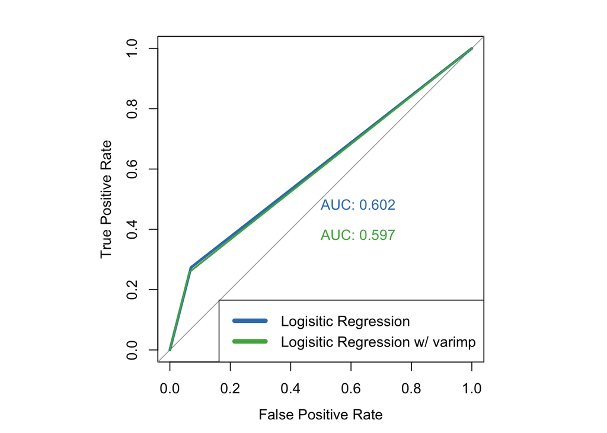

```r
legend("bottomright", legend=c("Logisitic Regression", "Logisitic Regression w/ varimp"), col=c("#377eb8", "#4daf4a"), lwd=5)
```

# Lasso Linear Regression

10-fold Cross Validation

MSE_test = 0.1591651

Company_Size_50_99 (0.100476835) → the people from company size (50-99) is less likely to stay.

City_Development_Index (city_development_index) → a decreased probability of leaving the company.

## Train and test datasets

```r
lasso_data_x <- model.matrix( ~ -1 + city_development_index+experience+training_hours+gender_Male+gender_Other+relevent_experience_No_relevent_experience+enrolled_university_no_enrollment+enrolled_university_Part_time_course+education_level_High_School+education_level_Masters+education_level_Phd+education_level_Primary_School+major_discipline_Business_Degree+major_discipline_Humanities+major_discipline_No_Major+major_discipline_Other+major_discipline_STEM+company_size_10_49+company_size_50_99+company_size_100_500+company_size_500_999+company_size_1000_4999+company_size_5000_9999+company_size_10000+company_type_Funded_Startup+company_type_NGO+company_type_Other+company_type_Public_Sector+company_type_Pvt_Ltd+last_new_job_1+last_new_job_2+last_new_job_3+last_new_job_4+last_new_job_never, results)

lasso_data_y <- results$target

# Total number of rows in the credit data frame
n <- nrow(results)

# Number of rows for the training set (70% of the dataset)
n_train <- round(0.7 * n)

# Create a vector of indices which is an 70% random sample
set.seed(123)
train_indices <- sample(1:n, n_train)

# Subset the credit data frame to training indices only
x_train <- lasso_data_x[train_indices, ]
y_train <- lasso_data_y[train_indices]

# Exclude the training indices to create the test set
x_test <- lasso_data_x[-train_indices, ]
y_test <- lasso_data_y[-train_indices]
```

```r
library(glmnet)
fit.lasso <- cv.glmnet(x_train, y_train, alpha = 1, nfolds = 10)
fit.lasso$lambda
```

```
##  [1] 0.1511197929 0.1376947270 0.1254623069 0.1143165814 0.1041610114
##  [6] 0.0949076342 0.0864763016 0.0787939853 0.0717941448 0.0654161509
## [11] 0.0596047603 0.0543096377 0.0494849192 0.0450888153 0.0410832493
## [16] 0.0374335266 0.0341080353 0.0310779714 0.0283170901 0.0258014779
## [21] 0.0235093457 0.0214208402 0.0195178718 0.0177839579 0.0162040801
## [26] 0.0147645543 0.0134529120 0.0122577923 0.0111688439 0.0101766346
## [31] 0.0092725704 0.0084488208 0.0076982508 0.0070143595 0.0063912231
## [36] 0.0058234444 0.0053061057 0.0048347259 0.0044052222 0.0040138744
## [41] 0.0036572928 0.0033323890 0.0030363488 0.0027666079 0.0025208301
## [46] 0.0022968865 0.0020928374 0.0019069155 0.0017375104 0.0015831548
## [51] 0.0014425117 0.0013143629 0.0011975985 0.0010912072 0.0009942673
## [56] 0.0009059394 0.0008254582 0.0007521268 0.0006853099 0.0006244289
## [61] 0.0005689563 0.0005184118 0.0004723575 0.0004303946 0.0003921595
## [66] 0.0003573212 0.0003255777 0.0002966543 0.0002703003 0.0002462876
## [71] 0.0002244081 0.0002044723 0.0001863075 0.0001697565 0.0001546758
## [76] 0.0001409348
```

### Predict the results

```r
yhat.train.lasso <- predict(fit.lasso, x_train, s = fit.lasso$lambda.min)  # Select lambda that minimizes validation MSE
yhat.test.lasso <- predict(fit.lasso, x_test, s = fit.lasso$lambda.min)


yhat.train.lasso_all <- predict(fit.lasso, x_train, s = fit.lasso$lambda)
yhat.test.lasso_all <- predict(fit.lasso, x_test, s = fit.lasso$lambda)
```

### Compute train and test MSEs

```r
mse_train <- colMeans((yhat.train.lasso_all - y_train) ** 2)
mse_test <- colMeans((yhat.train.lasso_all - y_test) ** 2)
mse.lassolinear.train <- mean((y_train - yhat.train.lasso)^2)
mse.lassolinear.test <- mean((y_test - yhat.test.lasso)^2)
```

### Aggregate all MSEs

```r
dd_mse <- data.table(
  lambda = fit.lasso$lambda,
  mse = mse_train,
  dataset = "Train",
  is_min = mse_train == min(mse_train)
)
dd_mse <- rbind(dd_mse, data.table(
  lambda = fit.lasso$lambda,
  mse = mse_test,
  dataset = "Test",
  is_min = mse_test == min(mse_test)
))
```

### Plot the MSE with lambda

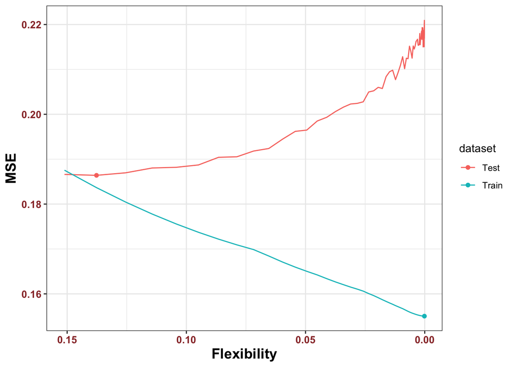

```r
ggplot(dd_mse, aes(lambda, mse, color=dataset)) +
  geom_line() +
  geom_point(data=dd_mse[is_min==TRUE]) +
  scale_y_continuous("MSE") +
  scale_x_reverse("Flexibility")
```

### Compute test MSE:

```r
print(mse.lassolinear.test)
```

```
## [1] 0.1591651
```

```r
print(mse.lassolinear.train)
```

```
## [1] 0.1550688
```

### Summary of the lasso linear regression

```r
coef(fit.lasso)
```

```
## 35 x 1 sparse Matrix of class "dgCMatrix"
##                                                      s1
## (Intercept)                                 1.101849227
## city_development_index                     -1.032391702
## experience                                 -0.002407587
## training_hours                              .
## gender_Male                                 .
## gender_Other                                .
## relevent_experience_No_relevent_experience  0.055454648
## enrolled_university_no_enrollment          -0.028594675
## enrolled_university_Part_time_course        .
## education_level_High_School                -0.078890639
## education_level_Masters                     .
## education_level_Phd                         .
## education_level_Primary_School             -0.068534902
## major_discipline_Business_Degree            .
## major_discipline_Humanities                 .
## major_discipline_No_Major                   .
## major_discipline_Other                      .
## major_discipline_STEM                       .
## company_size_10_49                          .
## company_size_50_99                          0.100476835
## company_size_100_500                        .
## company_size_500_999                        .
## company_size_1000_4999                      .
## company_size_5000_9999                      .
## company_size_10000                          .
## company_type_Funded_Startup                -0.024656158
## company_type_NGO                            .
## company_type_Other                          .
## company_type_Public_Sector                  .
## company_type_Pvt_Ltd                        .
## last_new_job_1                              .
## last_new_job_2                              .
## last_new_job_3                              .
## last_new_job_4                              .
## last_new_job_never                         -0.012386896
```

# Randomforest

## Preparation

```r
data <- read.csv("/Users/moonqj/Desktop/Boston University/Semester/Fall 2021/BA 810/Project/data/cleaned_data_810_10_06.csv")
data$target <- factor(data$target)
data$gender <- factor(data$gender)
data$relevent_experience <- factor(data$relevent_experience)
data$enrolled_university <- factor(data$enrolled_university)
data$education_level <- factor(data$education_level)
data$major_discipline <- factor(data$major_discipline)
data$experience <- factor(data$experience)
data$company_size <- factor(data$company_size)
data$company_type <- factor(data$company_type)
data$last_new_job <- factor(data$last_new_job)
```

##set train and test

```r
set.seed(123)
test_size <- floor(0.3*nrow(data))
sam <- sample(nrow(data), test_size, replace = FALSE)
train <- data[-sam, 1:12]
test <- data[sam, 1:12]
```

##set the model

```r
library(randomForest)
model <- randomForest(target~., data = train, importance = TRUE)
print(model)
```

```
##
## Call:
##  randomForest(formula = target ~ ., data = train, importance = TRUE)
##                Type of random forest: classification
##                      Number of trees: 500
## No. of variables tried at each split: 3
##
##         OOB estimate of  error rate: 22.41%
## Confusion matrix:
##      0    1 class.error
## 0 8960 1099   0.1092554
## 1 1906 1446   0.5686158
```

##predict and accuracy

```r
pred <- predict(model, test[, 1:11])
table(test=test[, 12], predict = pred)
```

```
##     predict
## test    0    1
##    0 3870  452
##    1  811  614
```

```r
accuracy <- mean(test[, 12] == pred)
print(accuracy)
```

```
## [1] 0.7802332
```

##variable importance

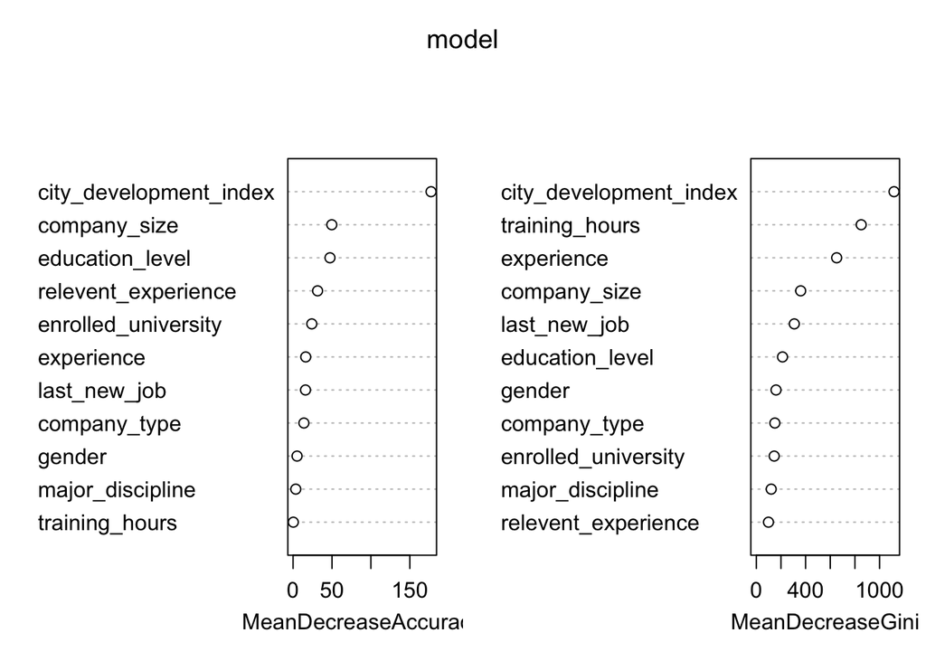

```r
varImpPlot(model)
```

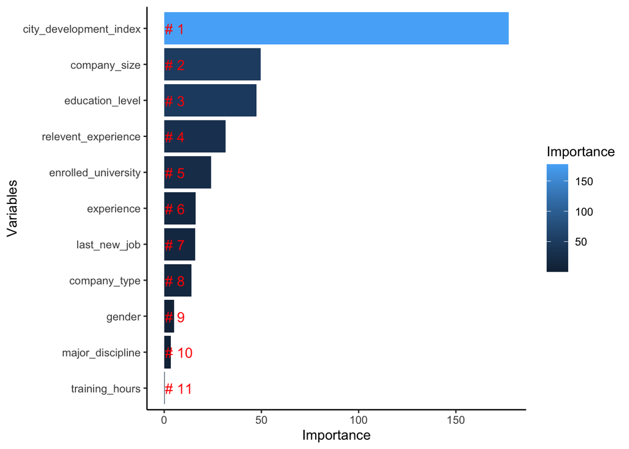

```r
library(ggplot2)
library(dplyr)
importance <-  importance(model)
varImportance <-  data.frame(Variables = row.names(importance),
                           Importance =round(importance[, "MeanDecreaseAccuracy"],2))
rankImportance <- varImportance %>%
  mutate(Rank=paste('#',dense_rank(desc(Importance))))

ggplot(rankImportance,aes(x=reorder(Variables,Importance),
                          y=Importance,fill=Importance)) +
  geom_bar(stat='identity') +
  geom_text(aes(x = Variables, y = 0.5, label = Rank),
            hjust=0, vjust=0.55, size = 4, colour = 'red') +
  labs(x = 'Variables') +
  coord_flip() +
  theme_classic()
```

# Decision Tree

```r
library(data.table)
library(rpart)
library(rpart.plot)
dd <- fread("/Users/moonqj/Desktop/Boston University/Semester/Fall 2021/BA 810/Project/data/cleaned_data_810_10_06.csv")
```

## create formula

```r
f1 <- as.formula(target ~ city_development_index + gender +
                   relevent_experience + enrolled_university    +
                   education_level  + major_discipline  +
                   experience   + company_size  +
                   company_type + last_new_job  +training_hours)
```

## split train test data

```r
set.seed(123)
test_size <- floor(0.3*nrow(data))
sam <- sample(nrow(data), test_size, replace = FALSE)
dd.train <- dd[-sam, c(1:12)]
dd.test <- dd[sam, c(1:12)]

x1.train <- model.matrix(f1, dd.train)[, -1]
y.train <- dd.train$target

x1.test <- model.matrix(f1, dd.test)[, -1]
y.test <- dd.test$target
```

## fit the tree

```r
fit.tree <- rpart(f1, dd.train, control = rpart.control(cp = 0.005))
```

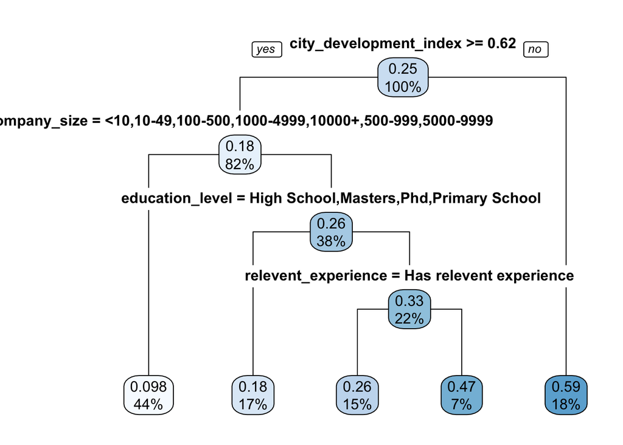

```r
rpart.plot(fit.tree, type = 1)
```

### calculate mse train and mse test

```r
ypred.train <- predict(fit.tree, dd.train)
mse.decisiontree.train <- mean((ypred.train - y.train) ^ 2)
print(mse.decisiontree.train)
```

```
## [1] 0.1527465
```

```r
ypred.test <- predict(fit.tree, dd.test)
mse.decisiontree.test <- mean((ypred.test - y.test) ^ 2)
print(mse.decisiontree.test)
```

```
## [1] 0.1495115
```

### Feature importance

```r
df <- data.frame(Feature_Importance = fit.tree$variable.importance)
df
```

```
##                        Feature_Importance
## city_development_index        335.9171943
## company_size                   75.8576799
## relevent_experience            46.0503465
## education_level                36.0739912
## enrolled_university            19.1108386
## last_new_job                   18.5833027
## experience                     10.2630228
## company_type                    0.1955906
```

# Boosting tree

```r
install.packages(c("gbm"), repos= 'https://github.com/gbm-developers/gbm.git')
library(ggthemes)
library(scales)
library(gbm)
```

## Load and split data

```r
dd_gbm <- fread("/Users/moonqj/Desktop/Boston University/Semester/Fall 2021/BA 810/Project/data/cleaned_data_810_10_06.csv", stringsAsFactors = T)

set.seed(123)
test_size <- floor(0.3*nrow(data))
sam <- sample(nrow(data), test_size, replace = FALSE)

dd_gbm.train <- dd_gbm[-sam, c(1:12)]
dd_gbm.test <- dd_gbm[sam, c(1:12)]

x1gbm.train <- model.matrix(f1, dd_gbm.train)[, -1]
ygbm.train <- dd_gbm.train$target

x1gbm.test <- model.matrix(f1, dd_gbm.test)[, -1]
ygbm.test <- dd_gbm.test$target
```

## Fit the tree

```r
fit_gbm <- gbm(f1, data = dd_gbm.train,
                 distribution = "gaussian",
                 n.trees = 100,
                 interaction.depth = 2,
                 shrinkage = 0.005)
```

### Get relative feature influence

```r
relative.influence(fit_gbm)
```

```
## n.trees not given. Using 100 trees.
```

```
## city_development_index                 gender    relevent_experience
##            10644.01285                0.00000               40.07430
##    enrolled_university        education_level       major_discipline
##               29.24479                0.00000                0.00000
##             experience           company_size           company_type
##                0.00000             2324.76219                0.00000
##           last_new_job         training_hours
##                0.00000                0.00000
```

```r
df2 <- data.frame(Relative_Influence = relative.influence(fit_gbm))
```

```
## n.trees not given. Using 100 trees.
```

```r
df2
```

```
##                        Relative_Influence
## city_development_index        10644.01285
## gender                            0.00000
## relevent_experience              40.07430
## enrolled_university              29.24479
## education_level                   0.00000
## major_discipline                  0.00000
## experience                        0.00000
## company_size                   2324.76219
## company_type                      0.00000
## last_new_job                      0.00000
## training_hours                    0.00000
```

### Calculate MSE train

```r
yhat.gbm <- predict(fit_gbm, dd_gbm.train, n.trees = 100)
mse.gbm.train <- mean((yhat.gbm - ygbm.train) ^ 2)
print(mse.gbm.train)
```

```
## [1] 0.1681107
```

### Calculate MSE test

```r
yhat.gbm_test <- predict(fit_gbm, dd_gbm.test, n.trees = 100)
mse.gbm.test <- mean((yhat.gbm_test - ygbm.test) ^ 2)
print(mse.gbm.test)
```

```
## [1] 0.1668571
```

# MSE Summary

```r
MSE_Test_Value <- c(mse.lassolinear.test, mse.logit.test, mse.logit.test.varimp, mse.decisiontree.test, mse.gbm.test)
MSE_Train_Value <- c(mse.lassolinear.train, mse.logit.train, mse.logit.train.varimp, mse.decisiontree.train, mse.gbm.train)

MSE_Test_Name <- c('mse.lassolinear.test', 'mse.logit.test', 'mse.logit.test.varimp', 'mse.decisiontree.test', 'mse.gbm.test')
MSE_Train_Name <- c('mse.lassolinear.train', 'mse.logit.train', 'mse.logit.train.varimp', 'mse.decisiontree.train', 'mse.gbm.train')

MSE_Table <- data.table(MSE_Test_Name, MSE_Test_Value, MSE_Train_Name, MSE_Train_Value)
MSE_Table
```

```
##            MSE_Test_Name MSE_Test_Value         MSE_Train_Name MSE_Train_Value
## 1:  mse.lassolinear.test      0.1591651  mse.lassolinear.train       0.1550688
## 2:        mse.logit.test      0.1587713        mse.logit.train       0.1545434
## 3: mse.logit.test.varimp      0.1629941 mse.logit.train.varimp       0.1589124
## 4: mse.decisiontree.test      0.1495115 mse.decisiontree.train       0.1527465
## 5:          mse.gbm.test      0.1668571          mse.gbm.train       0.1681107
```

```r
setorder(MSE_Table, cols = "MSE_Test_Value")
MSE_Table
```

```
##            MSE_Test_Name MSE_Test_Value         MSE_Train_Name MSE_Train_Value
## 1: mse.decisiontree.test      0.1495115 mse.decisiontree.train       0.1527465
## 2:        mse.logit.test      0.1587713        mse.logit.train       0.1545434
## 3:  mse.lassolinear.test      0.1591651  mse.lassolinear.train       0.1550688
## 4: mse.logit.test.varimp      0.1629941 mse.logit.train.varimp       0.1589124
## 5:          mse.gbm.test      0.1668571          mse.gbm.train       0.1681107
```

# Conclusion